# 1. Selecting CpGs for Age Prediction

Ellie Weise

2024-09-20

There are many sources of methylation variation among individuals in a population, from environmental effects to stress and life history. However, a small number of methylation sites (CpGs) have increasing methylation rates as individuals age. We used elastic net models to select these sites among the thousands of CpGs sequenced across the full-genome data we have for our test individuals.

## Cleaning Data Set

We’ve removed regions of the genome related to sex-determination, a putative inversion region, and mitochondrial and non-mapped regions to eliminate sources of bias within the genome (including CpGs that are related to sex-determination or inversion rather than age). Additionally, elastic net models do not accomodate missing data, so any CpG sites that contain NAs are removed.

```r
#remove CpGs with NAs for the model
nas <- colSums(is.na(allCpGs1))
allCpGs1 <- allCpGs1[,which(nas < 1)]

#remove non-mapped scaffold and mitochondrial data from data set
allCpGs1 <- allCpGs1[,which(!(grepl(pattern = "NW",
                                    colnames(allCpGs1),perl = T)))]
allCpGs1 <- allCpGs1[,which(!(grepl(pattern = "NC_009709.1",
                                    colnames(allCpGs1),perl = T)))]

# remove sex-det and inversion chromosomes
allCpGs1 <- allCpGs1[,which(!(grepl(pattern = "NC_047158.1",
                                    colnames(allCpGs1),perl = T)))]
allCpGs1 <- allCpGs1[,which(!(grepl(pattern = "NC_047162.1",
                                    colnames(allCpGs1),perl = T)))]
```

## Prepping to Run Models

We log age data prior to running the model, and the CpG selected is repeated 100 times with different training and testing sets. This was repeated with sex-separated clocks as well (glmnet R script) but it is shorted to just the full model here since that is what we ended up using.

```r
#log age data
sexdata <- sexdata %>%
  mutate(LogAge = log(Age),LogLen = log(Length))
```

```r
#create blank objects for storing outputs in loop
modelout <- data.frame(matrix(data = NA,nrow = 100, ncol = 13))
colnames(modelout) <- c("Train_cor","Test_cor","Train_MAE","Test_MAE","lambda.1se")
CpGlist <- list()

predout <- data.frame(indivname = sexdata$indivname,
                      LogAge = sexdata$LogAge)
```

## Run 100 Elastic Net Model Replicates

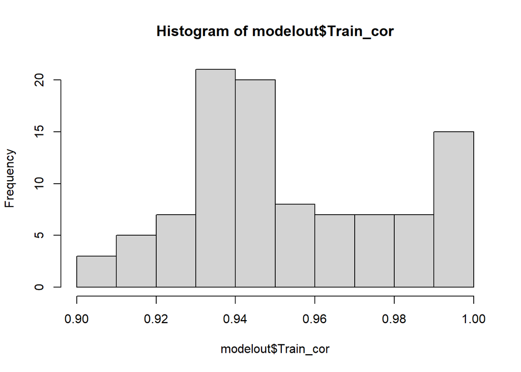

```r
##Loop for glmnet testing with all CpG sites ####
i <- 1
for (i in 1:100) {
  #print(i)
  #set a different seed so different train/test and a separate model are constructed
  set.seed(Sys.time())

  #randomly select individuals for testing
  testpick <- sexdata %>%
    group_by(Age,ObsSex) %>%
    slice_sample(n = 1)

  #sort other individuals into training data
  trainpick <- sexdata[which(!(sexdata$indivname %in% testpick$indivname)),]

  #select CpG sites for each group
  testdat <- allCpGs1[which(allCpGs1$indivname %in% testpick$indivname),]
  testdat <- full_join(testpick,testdat,by = "indivname")

  traindat <- allCpGs1[which(!(allCpGs1$indivname %in% testpick$indivname)),]
  traindat <- full_join(trainpick,traindat,by = "indivname")

  #select data and run glmnet to select sites
  y <- traindat$LogAge
  x <- as.matrix(traindat[,-1:-5])

  model1 <- cv.glmnet(x,y,family = "gaussian",alpha = 0.5,nfolds = 10)
  coef.allCpG <- as.matrix(coef(model1,s = "lambda.min"))

  bestCpGnames <- names(coef.allCpG[which(coef.allCpG > 0),])

  #predict testdat
  ytest <- testdat$LogAge
  xtest <- as.matrix(testdat[,-1:-5])

  #predict and correlate train data
  pred_logage <- predict(model1,newx = x,type = "response",s = model1$lambda.min)
  train_cor <- cor.test(y,pred_logage)

  #predict and correlate test data
  pred_logage_test <- predict(model1,newx = xtest,type = "response",s = model1$lambda.min)
  test_cor <- cor.test(ytest,pred_logage_test)

  #uncertainty for train and test
  train_MAE <- median(abs(exp(y) - exp(pred_logage[ ,1])))
  test_MAE <- median(abs(exp(ytest) - exp(pred_logage_test[ ,1])))

  ##save outputs
  modelout[i,5] <- model1$lambda.min
  CpGlist[[i]] <- bestCpGnames

  modelout[i,1] <- train_cor$estimate
  modelout[i,2] <- test_cor$estimate

  modelout[i,3] <- train_MAE
  modelout[i,4] <- test_MAE

  #save predictions
  #full model
  trainpred <- data.frame(indivname = trainpick$indivname,
                          LogAge = trainpick$LogAge,
                          predage = pred_logage)
  testpred <- data.frame(indivname = testpick$indivname,
                          LogAge = testpick$LogAge,
                          predage = pred_logage_test)
  predout_tmp <- rbind(trainpred,testpred)
  predout <- full_join(predout,predout_tmp, by = c("indivname","LogAge"))
}

hist(modelout$Train_cor)
```

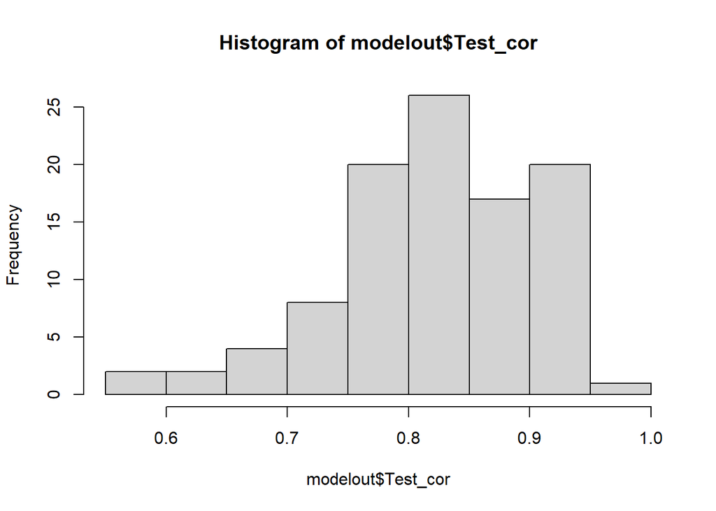

```r
hist(modelout$Test_cor)
```

```r
#concatenate all the best CpGs
CpGlist_best <- CpGlist[[1]]
for (i in 2:100) {
  CpGlist_best <- c(CpGlist_best,CpGlist[[i]])
}

counting <- data.frame(CpGlist_best) %>%
  group_by_all() %>%
  count() %>%
  arrange(desc(n))
table(counting$n)
```

```
##
##   1   2   3   4   5   6   7   8   9  10  11  12  13  15  17  18  19  20  22  25
## 111  40  24  20  14  10   4   7   3   7   5   5   4   1   5   2   1   2   1   1
##  26  28  30  32  33  35  36  38  39  41  42  43  48  52  53  58  61  63  71  75
##   1   1   1   1   3   1   1   2   1   1   1   2   1   2   1   1   1   1   1   1
##  76  90  93  95 100
##   2   1   1   1   1
```

```r
top_CpG_group <- counting %>%
  arrange(desc(n)) %>%
  filter(n > 20)
```

## Repeat Loop with Length

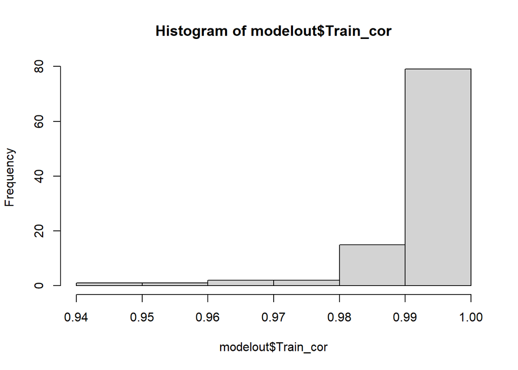

```r
#create blank objects for storing outputs in loop
modelout <- data.frame(matrix(data = NA,nrow = 100, ncol = 13))
colnames(modelout) <- c("Train_cor","Test_cor","Train_MAE","Test_MAE","lambda.1se")
CpGlist <- list()

predout <- data.frame(indivname = sexdata$indivname,
                      LogLen = sexdata$LogLen)

##Loop for glmnet testing with all CpG sites ####
i <- 1
for (i in 1:100) {
  #print(i)
  set.seed(Sys.time())

  #randomly select individuals for testing
  testpick <- sexdata %>%
    group_by(Age,ObsSex) %>%
    slice_sample(n = 1)

  #sort other individuals into training data
  trainpick <- sexdata[which(!(sexdata$indivname %in% testpick$indivname)),]

  #select CpG sites for each group
  testdat <- allCpGs1[which(allCpGs1$indivname %in% testpick$indivname),]
  testdat <- full_join(testpick,testdat,by = "indivname")

  traindat <- allCpGs1[which(!(allCpGs1$indivname %in% testpick$indivname)),]
  traindat <- full_join(trainpick,traindat,by = "indivname")

  #select data and run glmnet to select sites
  y <- traindat$LogLen
  x <- as.matrix(traindat[,-1:-6])

  model1 <- cv.glmnet(x,y,family = "gaussian",alpha = 0.5,nfolds = 10)
  coef.allCpG <- as.matrix(coef(model1,s = "lambda.min"))

  bestCpGnames <- names(coef.allCpG[which(coef.allCpG > 0),])

  #predict testdat
  ytest <- testdat$LogLen
  xtest <- as.matrix(testdat[,-1:-6])

  #predict and correlate train data
  pred_LogLen <- predict(model1,newx = x,type = "response",s = model1$lambda.min)
  train_cor <- cor.test(y,pred_LogLen)

  #predict and correlate test data
  pred_LogLen_test <- predict(model1,newx = xtest,type = "response",s = model1$lambda.min)
  test_cor <- cor.test(ytest,pred_LogLen_test)

  #uncertainty for train and test
  train_MAE <- median(abs(exp(y) - exp(pred_LogLen[ ,1])))
  test_MAE <- median(abs(exp(ytest) - exp(pred_LogLen_test[ ,1])))

  ##save outputs
  modelout[i,5] <- model1$lambda.min
  CpGlist[[i]] <- bestCpGnames

  modelout[i,1] <- train_cor$estimate
  modelout[i,2] <- test_cor$estimate

  modelout[i,3] <- train_MAE
  modelout[i,4] <- test_MAE

  #save predictions
  #full model
  trainpred <- data.frame(indivname = trainpick$indivname,
                          LogLen = trainpick$LogLen,
                          predlen = pred_LogLen)
  testpred <- data.frame(indivname = testpick$indivname,
                         LogLen = testpick$LogLen,
                         predlen = pred_LogLen_test)
  predout_tmp <- rbind(trainpred,testpred)
  predout <- full_join(predout,predout_tmp, by = c("indivname","LogLen"))
}

hist(modelout$Train_cor)
```

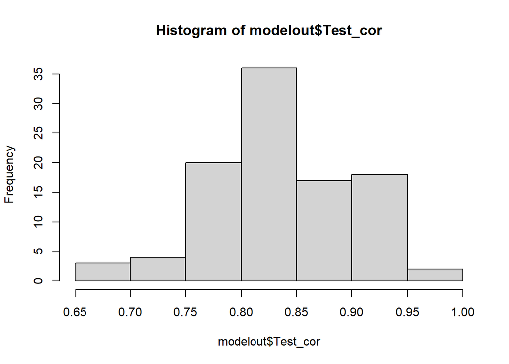

```r
hist(modelout$Test_cor)
```

```r
#concatenate all the best CpGs
CpGlist_best_len <- CpGlist[[1]]
for (i in 2:100) {
  CpGlist_best_len <- c(CpGlist_best_len,CpGlist[[i]])
}

counting <- data.frame(CpGlist_best_len) %>%
  group_by_all() %>%
  count() %>%
  arrange(desc(n))
table(counting$n)
```

```
##
##   1   2   3   4   5   6   7   8   9  10  11  12  13  14  15  16  17  18  19  20
## 170  53  34  26  17  13  14   7   8   9  13   7   5   6   2   3   5   6   2   2
##  22  23  24  25  28  29  30  31  32  34  35  36  37  38  39  42  45  46  47  49
##   3   2   2   1   3   2   3   1   3   1   1   5   1   1   2   2   1   1   1   1
##  51  52  53  56  58  59  62  66  69  74  85  88  89  95
##   1   1   1   2   2   1   1   1   1   1   1   1   1   2
```

```r
top_CpG_group_len <- counting %>%
  arrange(desc(n)) %>%
  filter(n > 20) %>%
  rename(CpGlist_best = CpGlist_best_len)
```

## Concatenate the best CpGs across replicates

```r
CpGlist_best_comb <- unique(rbind(top_CpG_group,top_CpG_group_len))

#write.csv(CpGlist_best_comb,file = "Output/CpGList_LengthAge.csv",row.names = F)
```

## Figures - look at correlation and MAE values for age prediction